# Homophily function

Here is a first approximation at how to defend our choice of a symmetric homophily function. The function we currently use in the paper is:

$$P(x_{ij}) = c \cdot \exp(- \beta \gamma)$$
Where $\gamma$ is the absolute ideological distance (in percentiles) between ego and alter, the parameter $\beta$ regulates the strength of homophily preferences, and c is a normalizing constant.

*First, one issue I noticed in our paper* is that $\gamma$ should be defined in terms of the original ideological scale and not in terms of percentiles. Because the ideological distribution in percentiles is by definition a uniform distribution, the result of applying this function is a uniform realized homophilous tendency across egos. This does not resemble the data. Instead, if we define $\gamma$ as the ideological distance in the original scale, the same homophily parameter $\beta$ produces differential realized homophily because of the population structure, which is our point, and also, fits the data much better.

Now, to test whether a model with differential homophily fits the data better than one without it I define the following homophily function:

$$\begin{aligned}
P(x_{ij}) &= c \cdot \exp(- \beta \gamma\eta) \\
\eta &= \left(\frac{i}{100}\right)^k
\end{aligned}$$
Where I introduce a parameter $\eta$ that regulates the extent of the asymmetry. $i$ is the ideology percentile of the ego. Homophily is symmetrical at $k = 0$ and asymmetrical for any other values. Conservatives are more willing to form close ties than liberals for $k > 0$ and liberals more homophilous than conservatives for $k < 0$. The same absolute values but to the right and left of 0 do not correspond to the same degree of asymmetry (see the figure) but this shouldn’t be much of a problem since from the data we know that, if anything, the asymmetry is on conservatives being more homophilous than liberals.

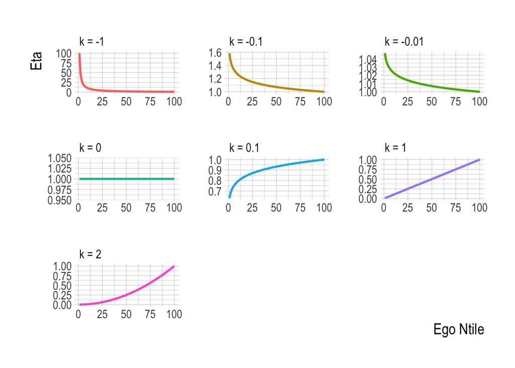

## Likelihood of forming a tie at different k and $\beta$ values

Notice how, given the homophily function above, the likelihood of forming a tie is uniform over ego-alter distance for both conservatives and liberals when $\beta = 0$ (first row). When there is homophily ($\beta > 0$), even if the function is symmetrical ($k = 0$) there is a realized asymmetry between cons and libs due to the population structure. As $k$ increases, the asymmetry in the likelihood of forming a tie to a distant alter becomes more stark.

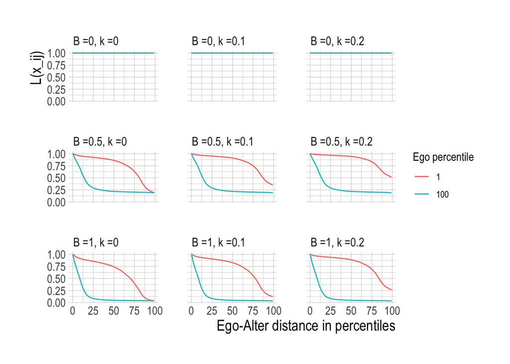

## Simulation examples

Here are some examples of what happens when you simulate networks under different $\beta$ and $k$ parameters.

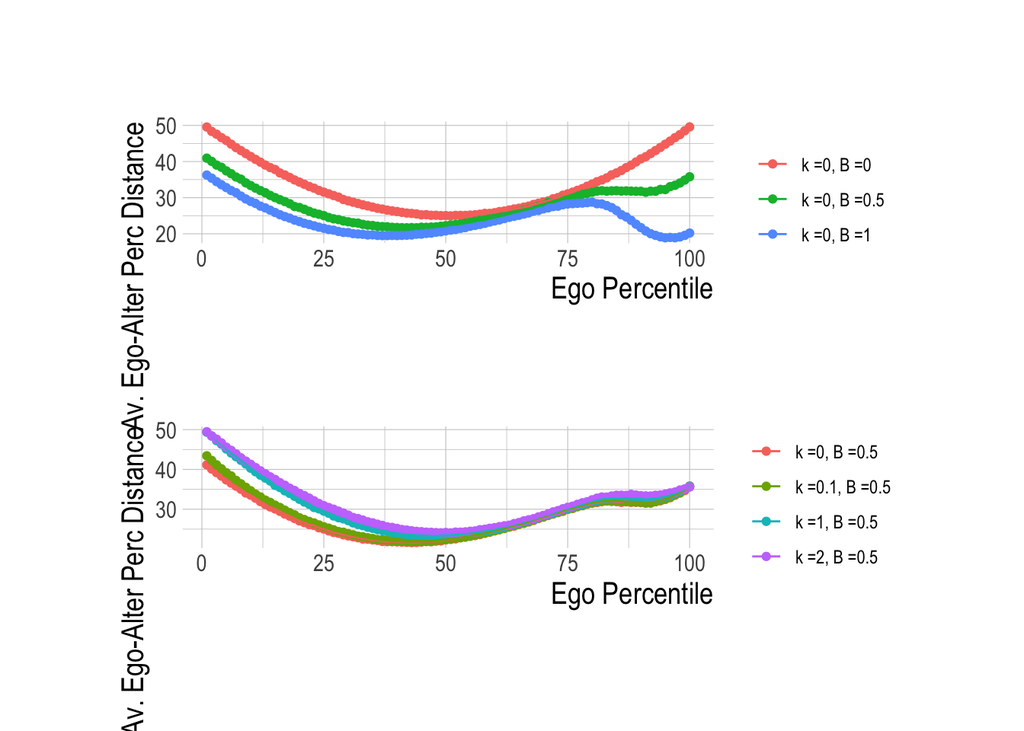

## Null Model

I define a null model in which $k = 0$ and $\beta = 0$ and compare the results of the simulated networks to the observed homophily distribution using ks distance. Over a hundred iterations, *the average ks distance is around 0.58*. The figure shows the difference between one realization of the simulation (in black) and the observed values (in red).

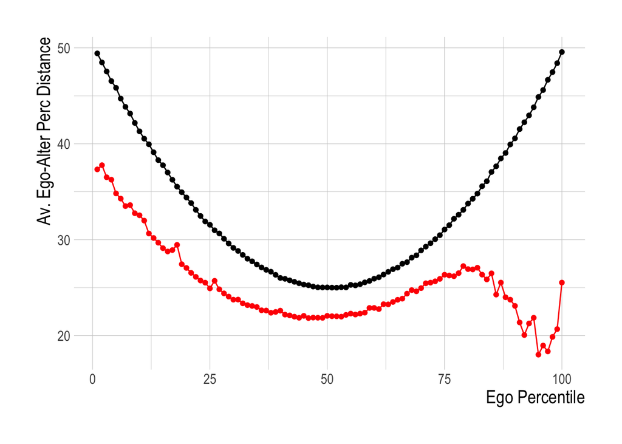

## Symmetric Model

Now I compare to the data the same model but with $k = 0$ (the symmetry parameter) and varying values of $\beta$ (the overall homophily strength). I then take the value of $\beta$ that minimizes the ks distance between the simulated and the observed homophily distribution and run 100 simulations with that value. In our case $\beta = 0.8$ minimizes the ks distance, and for this value the average ks distance is around 0.17.

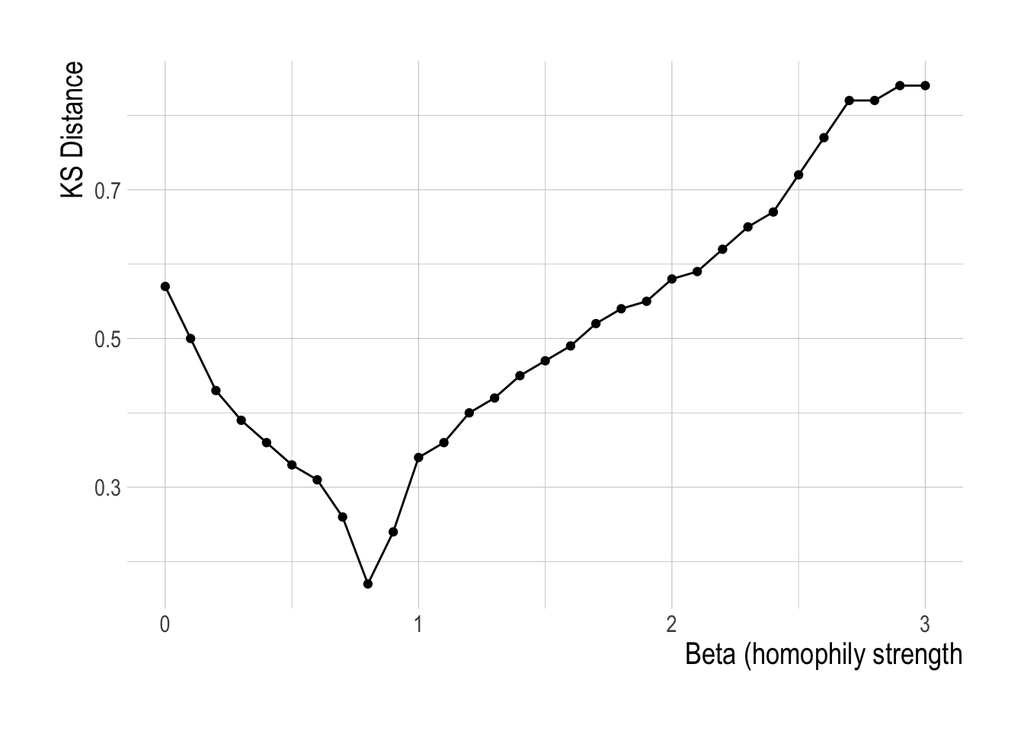

## Assymetric Model

Here I vary values of both parameters. The figure shows how simulations from models with values of beta around 0.8 and no asymmetry as well as models with much higher homophily and strong asymmetry fit the data similarly. The lowest ks distance value produced is 0.14 (with $k = 1.7$ and $\beta = 2$), which is only slightly lower than the symmetric model.

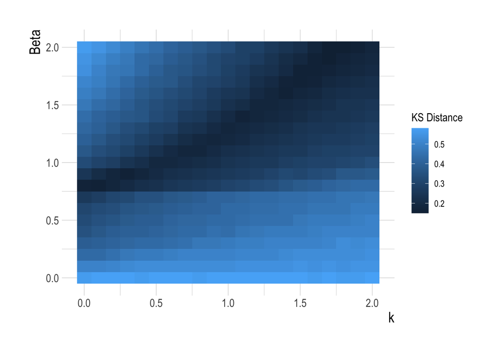